# examples_0427

The correct answer should have reflective symmetry across the $y=x$ line, also known as the 45$^\circ$ line.

So, the correct answer is C:

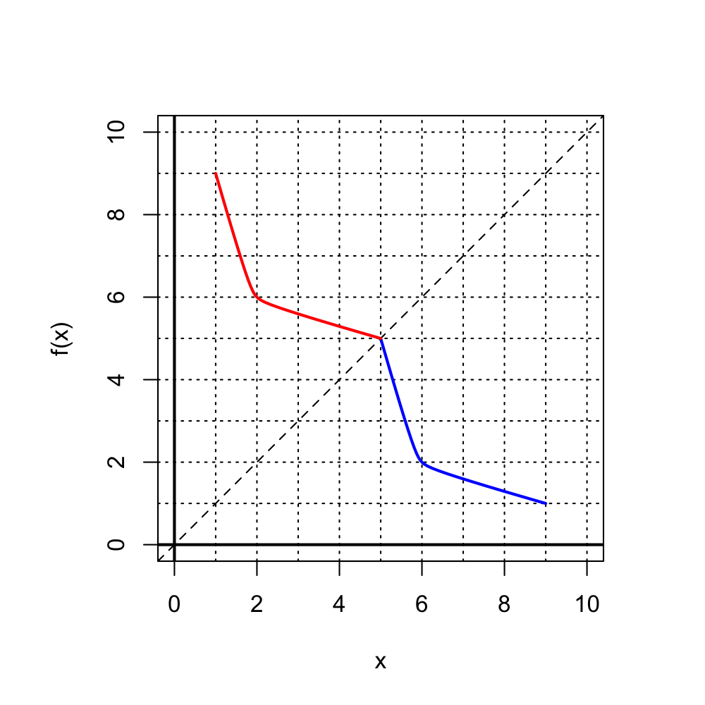

The [one-to-one](https://en.wikipedia.org/wiki/Injective_function) function $f$ is plotted below:

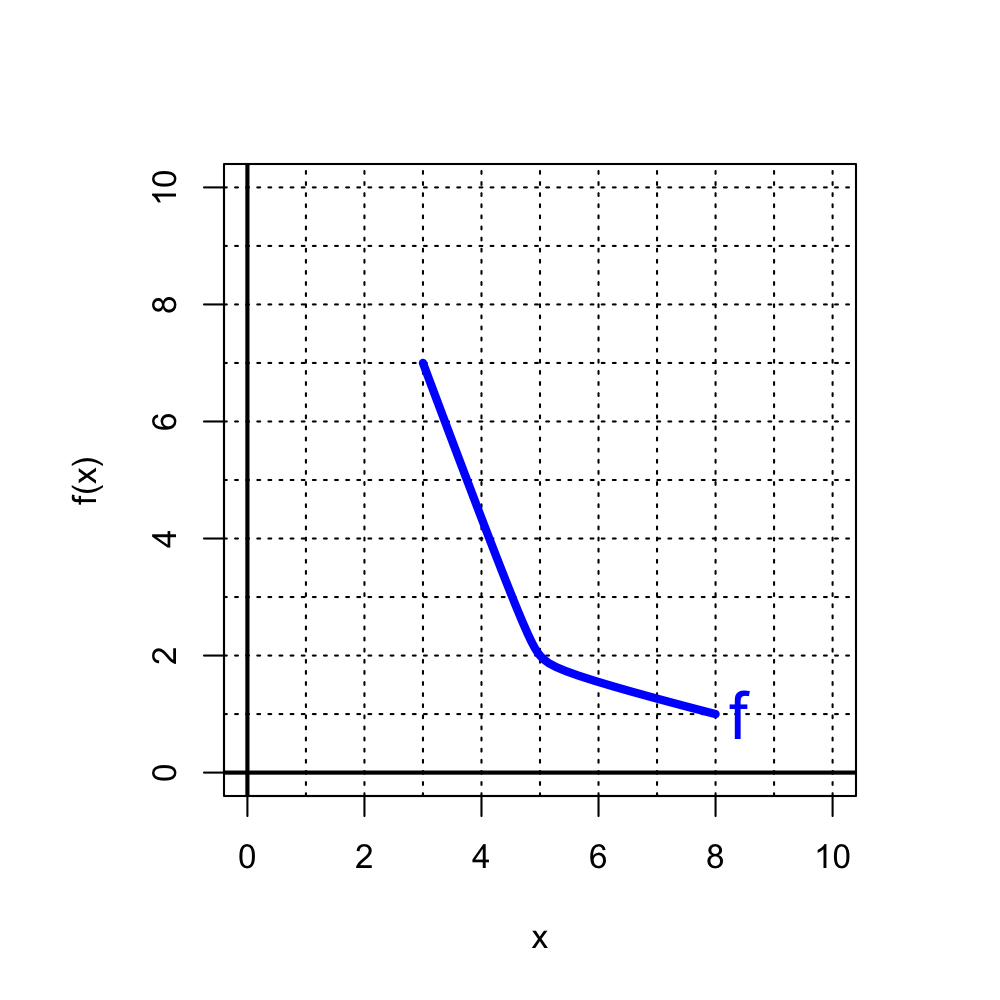

Which of the following red curves is a graph of the inverse function, $f^{-1}$?

- A

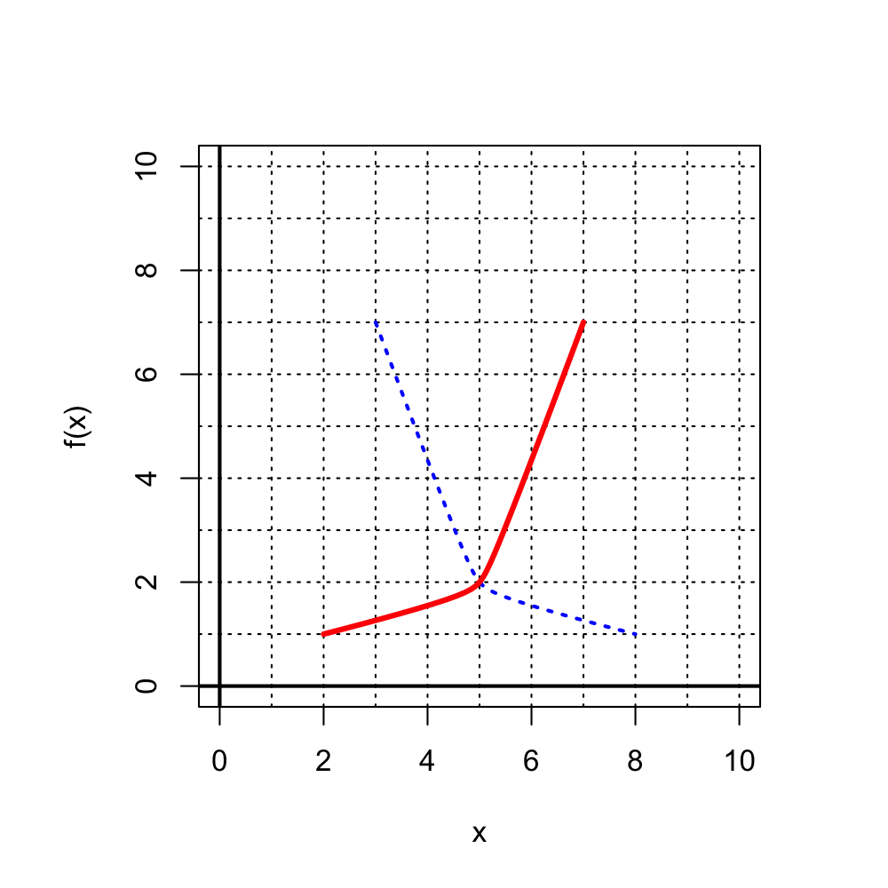

- B

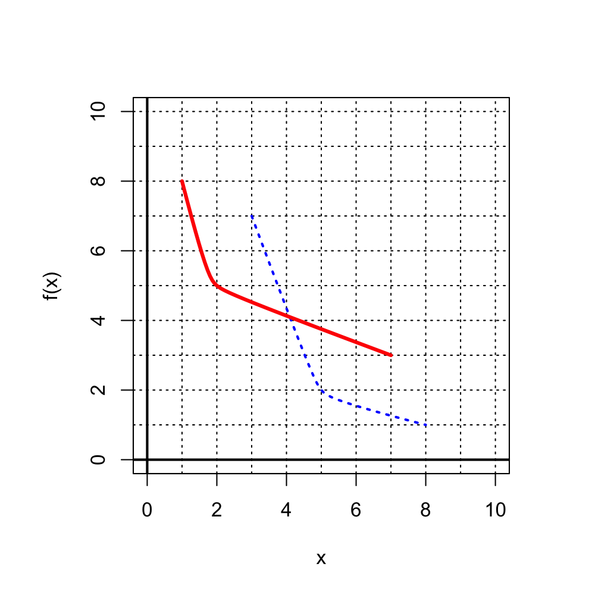

- C

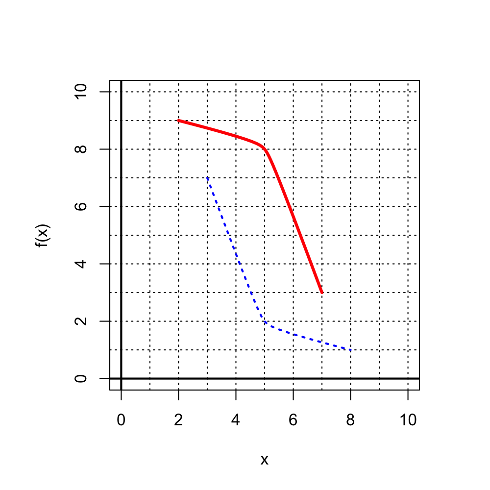

- D

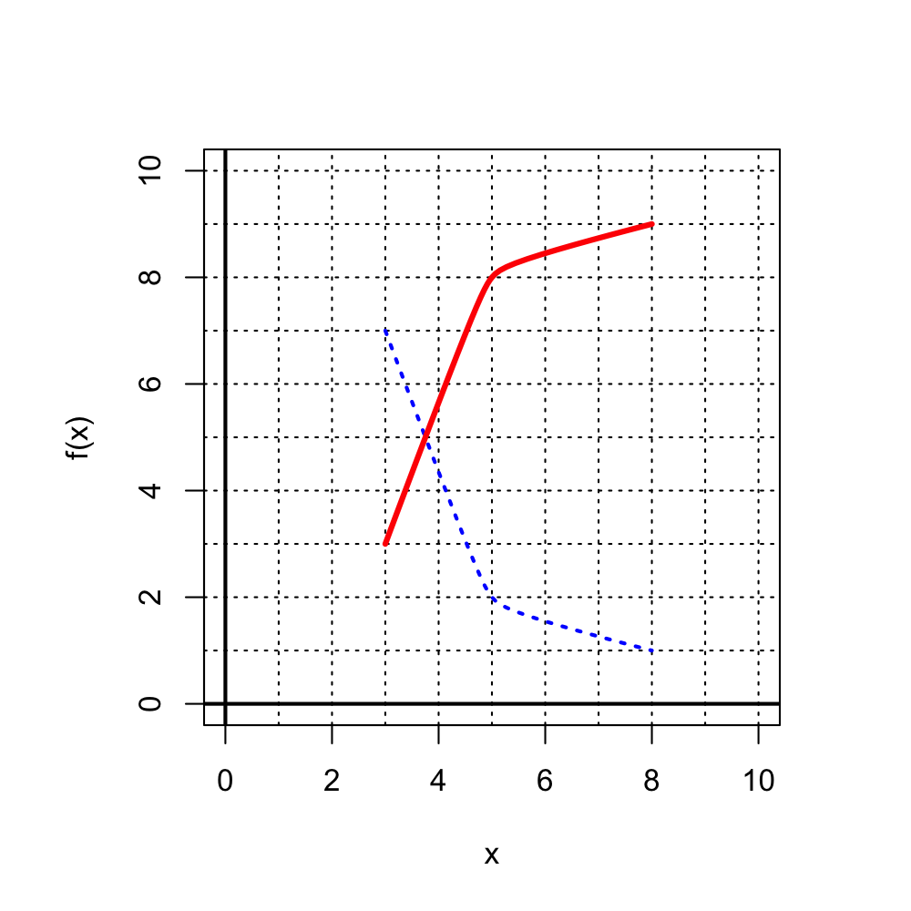

ABCD

The correct answer should have reflective symmetry across the $y=x$ line, also known as the 45$^\circ$ line.

So, the correct answer is B:

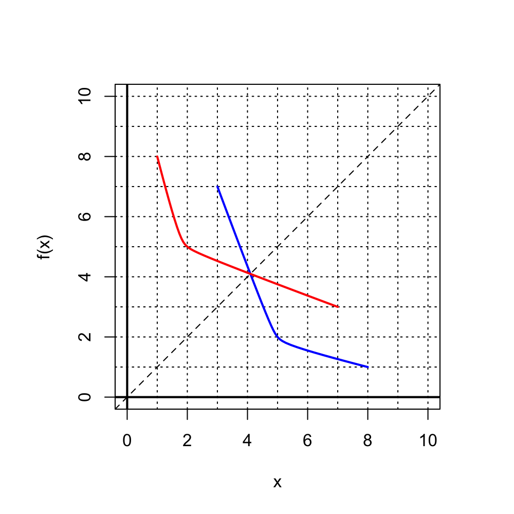

The [one-to-one](https://en.wikipedia.org/wiki/Injective_function) function $f$ is plotted below:

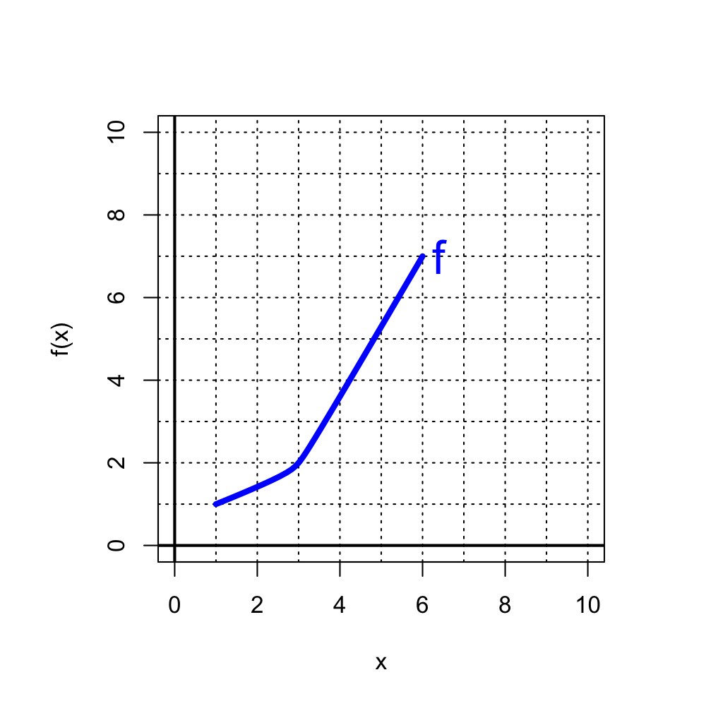

Which of the following red curves is a graph of the inverse function, $f^{-1}$?

- A

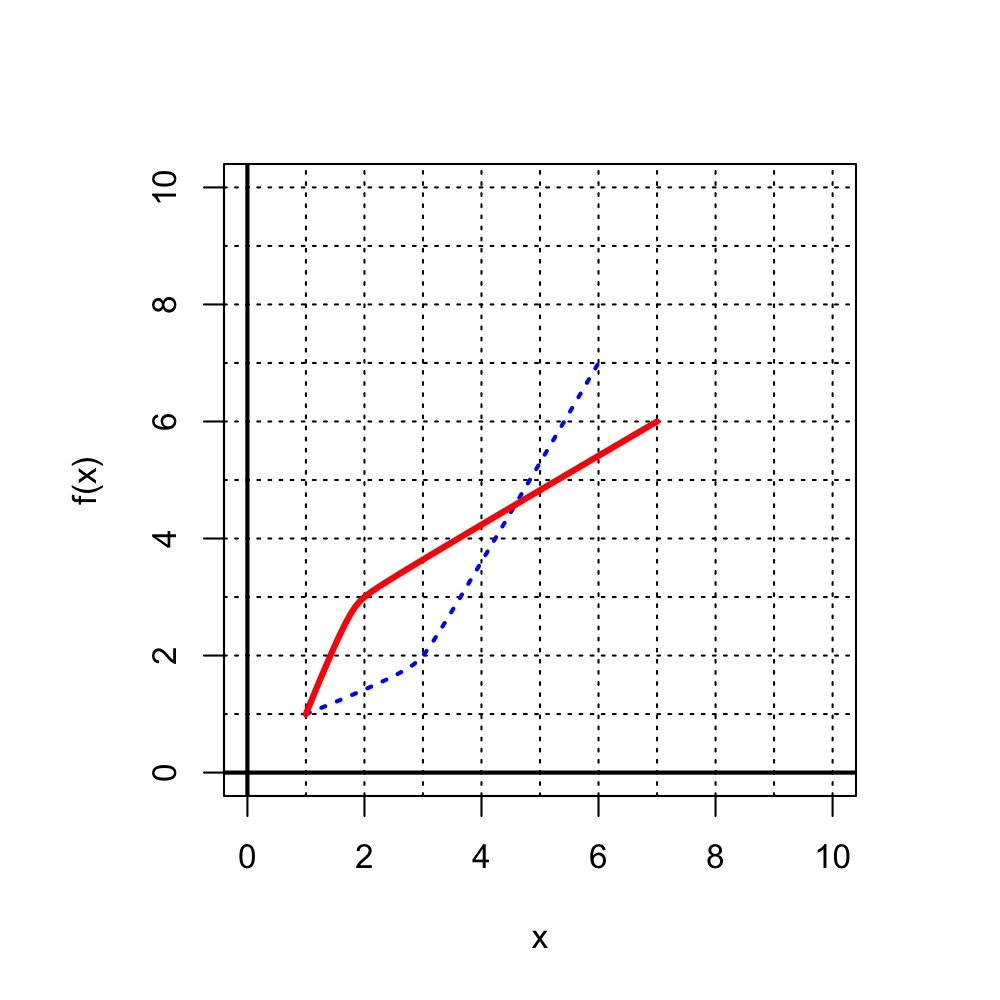

- B

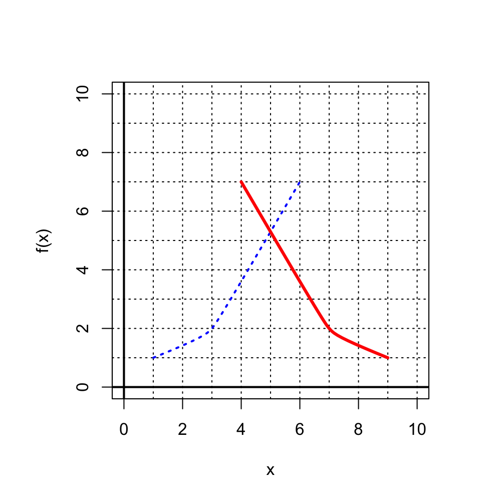

- C

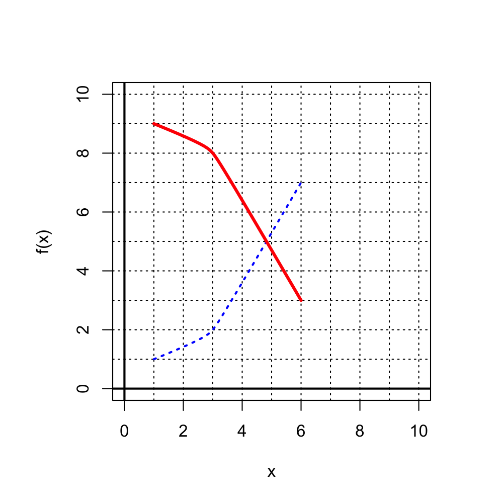

- D

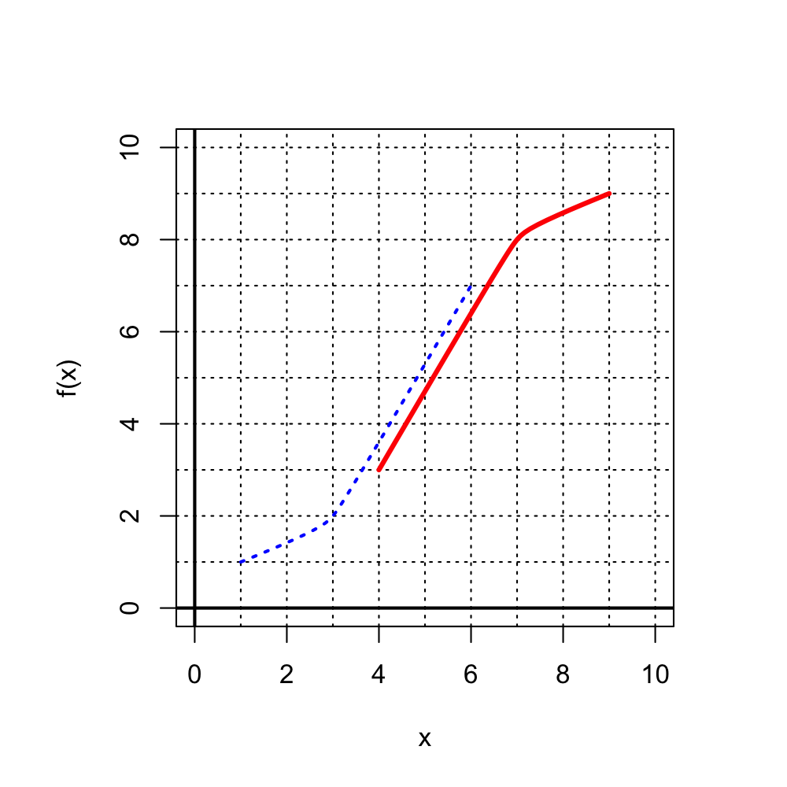

ABCD

The correct answer should have reflective symmetry across the $y=x$ line, also known as the 45$^\circ$ line.

So, the correct answer is A:

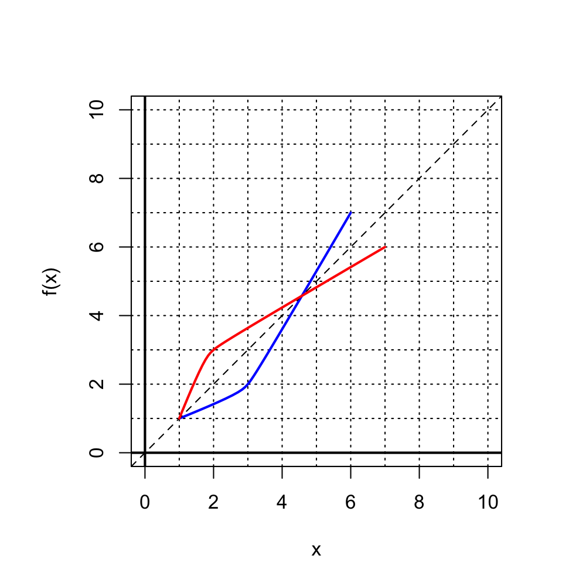

The [one-to-one](https://en.wikipedia.org/wiki/Injective_function) function $f$ is plotted below:

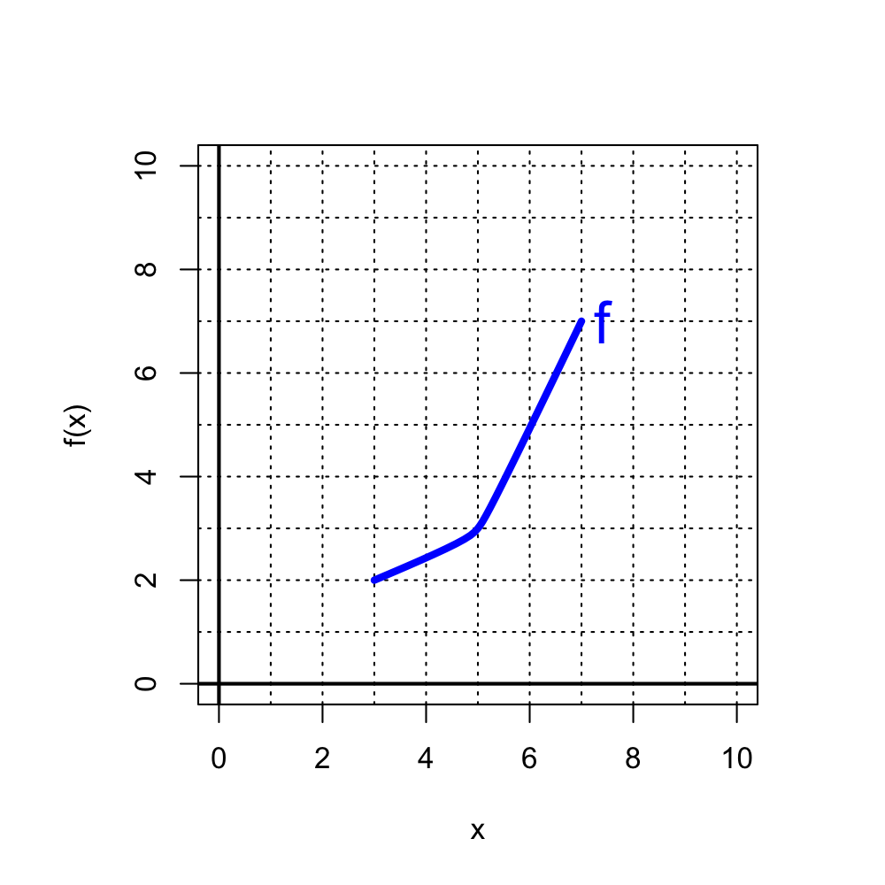

Which of the following red curves is a graph of the inverse function, $f^{-1}$?

- A

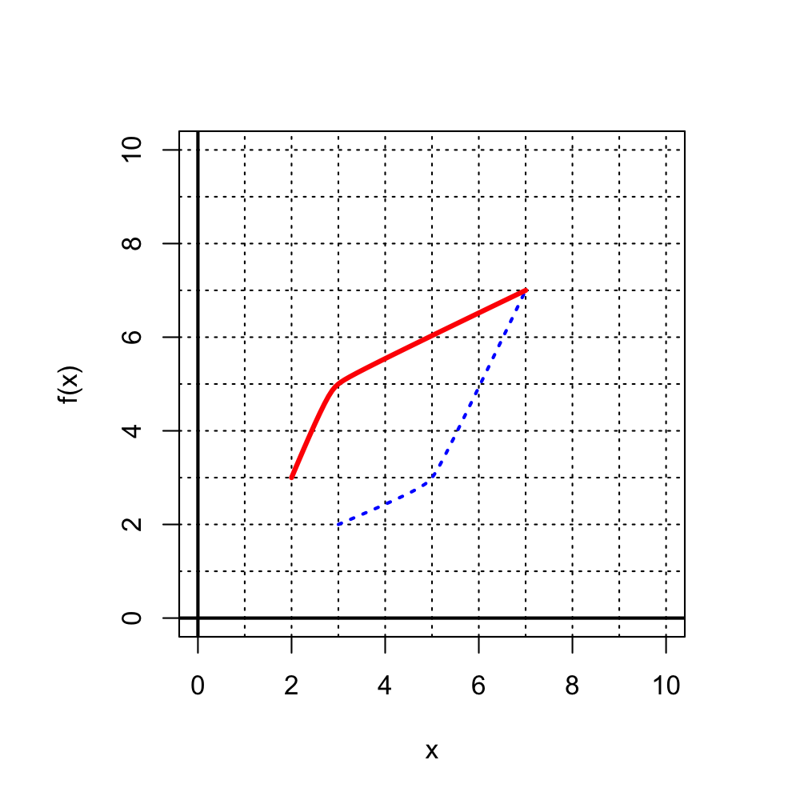

- B

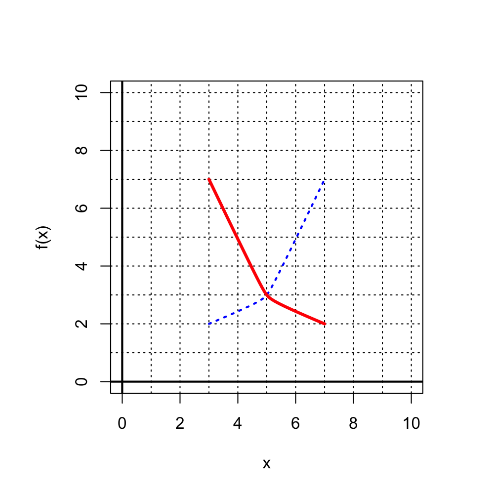

- C

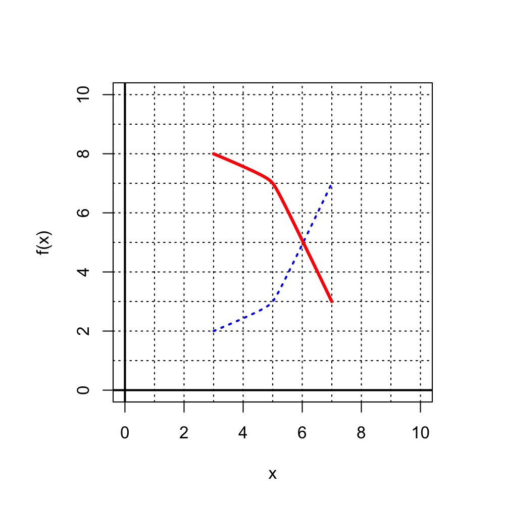

- D

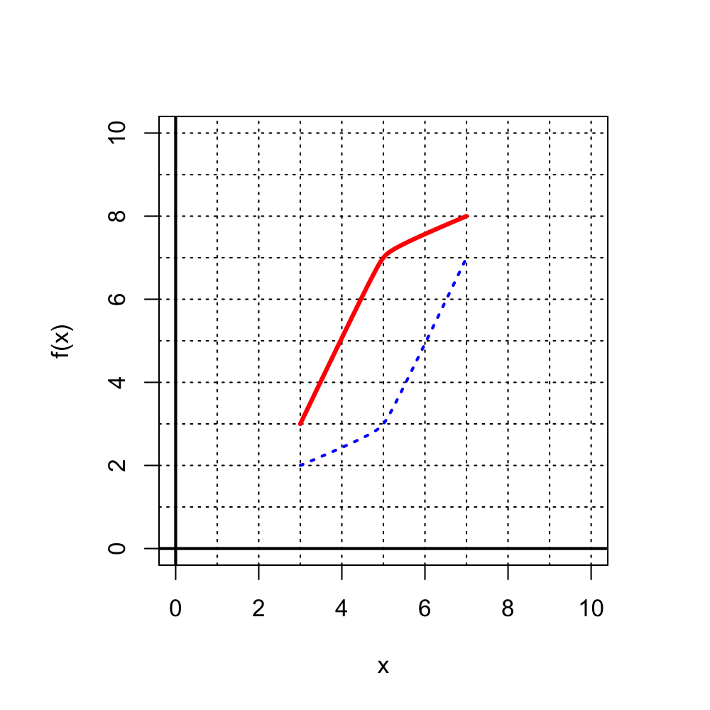

ABCD

The correct answer should have reflective symmetry across the $y=x$ line, also known as the 45$^\circ$ line.

So, the correct answer is A:

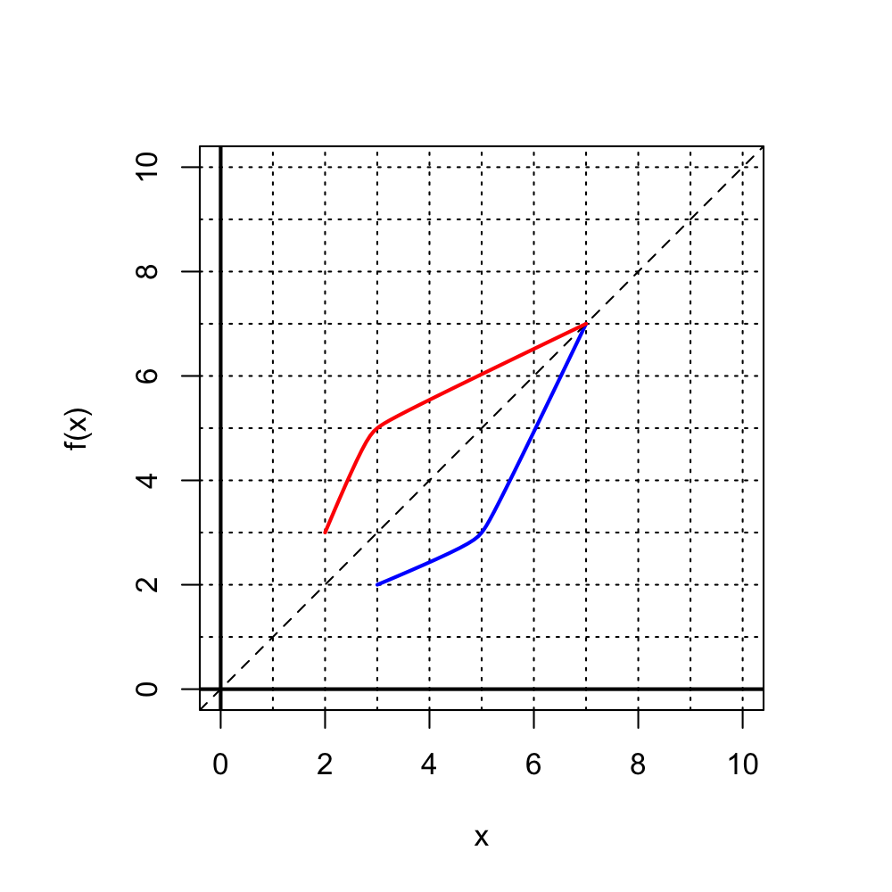

The [one-to-one](https://en.wikipedia.org/wiki/Injective_function) function $f$ is plotted below:

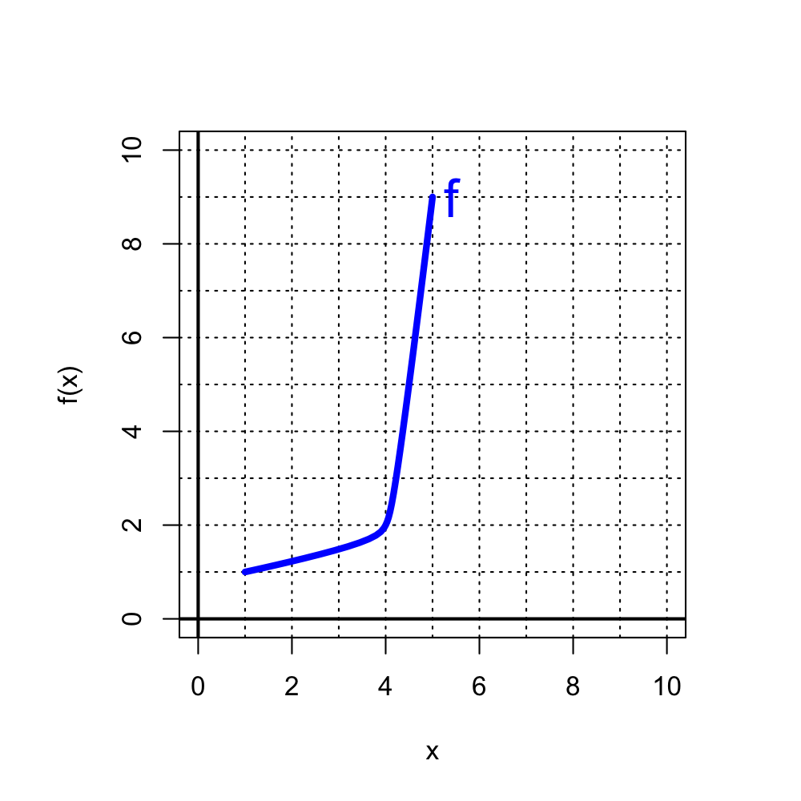

Which of the following red curves is a graph of the inverse function, $f^{-1}$?

- A

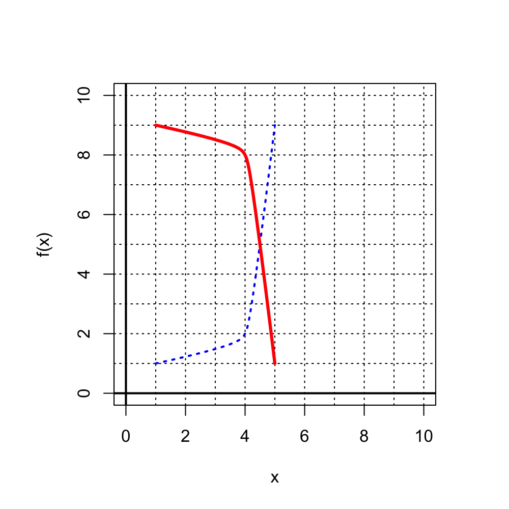

- B

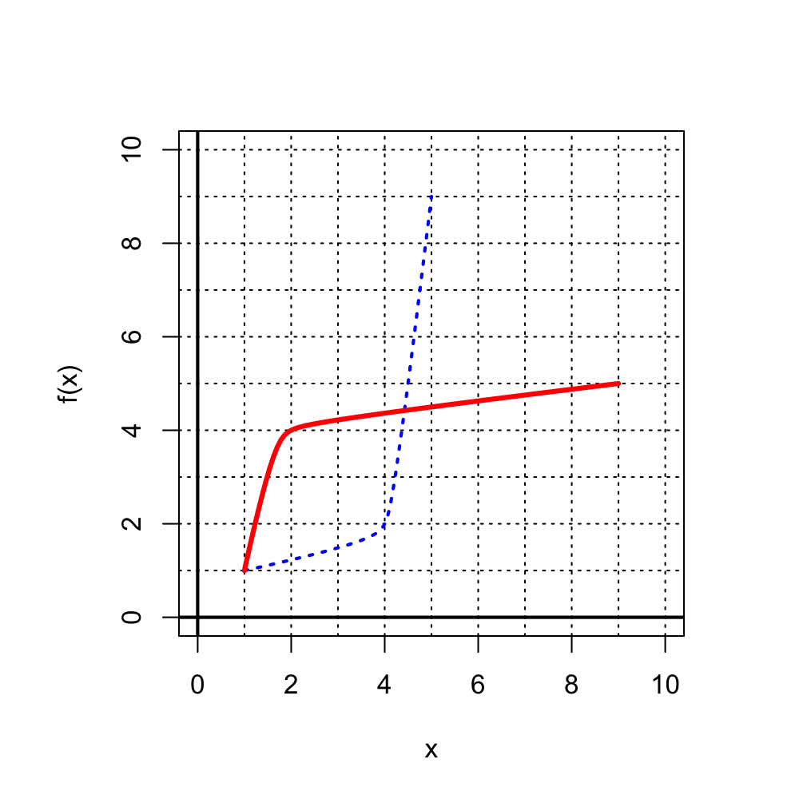

- C

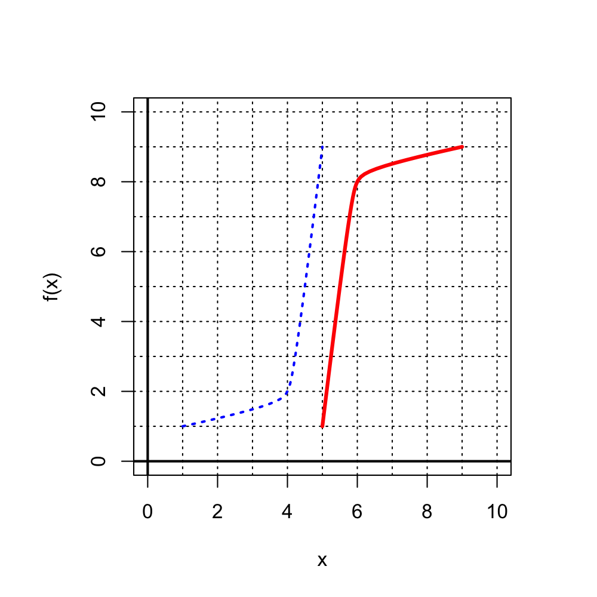

- D

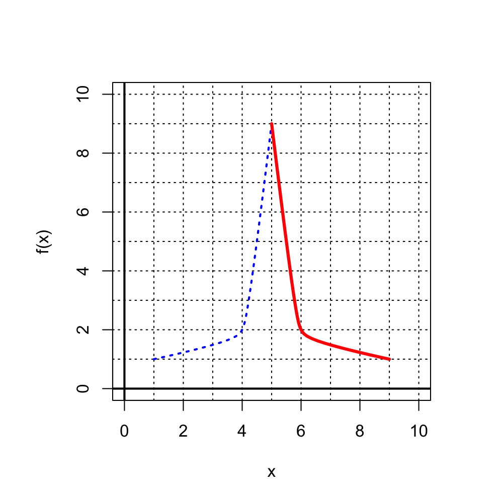

ABCD

The correct answer should have reflective symmetry across the $y=x$ line, also known as the 45$^\circ$ line.

So, the correct answer is B:

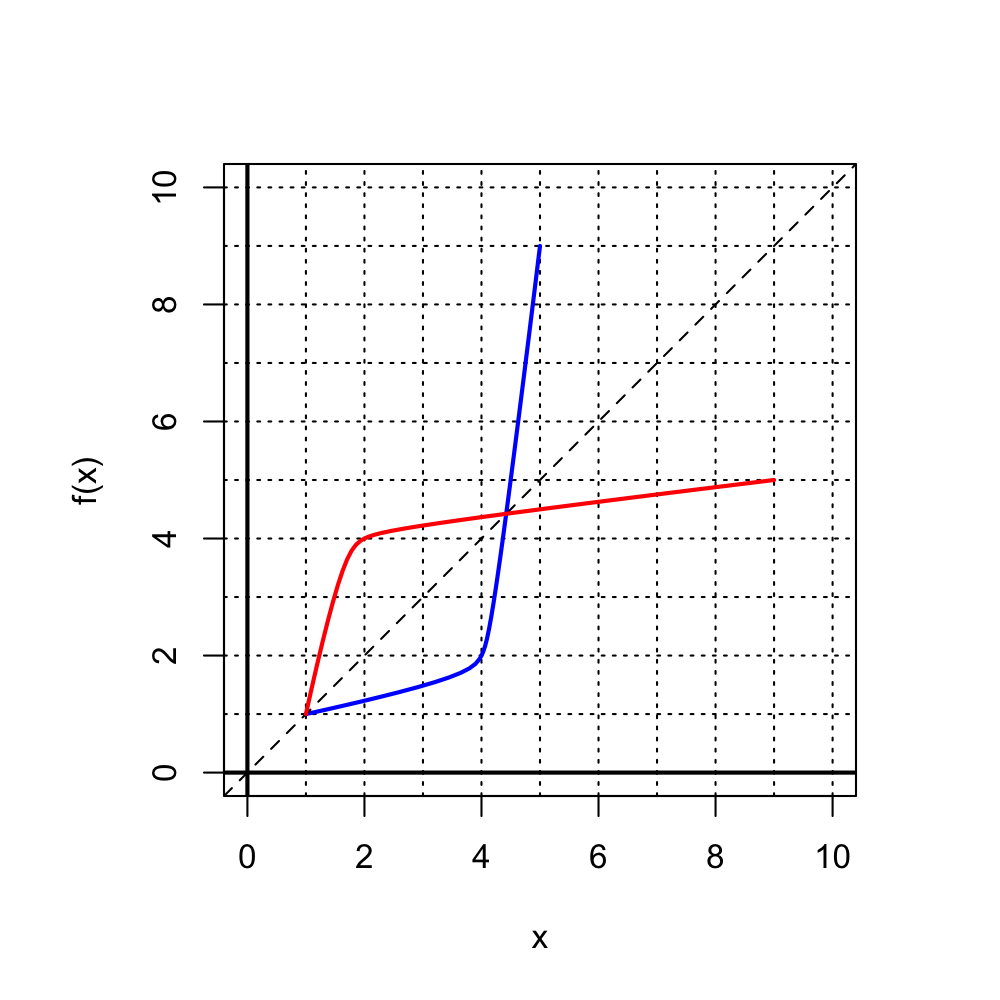

The [one-to-one](https://en.wikipedia.org/wiki/Injective_function) function $f$ is plotted below:

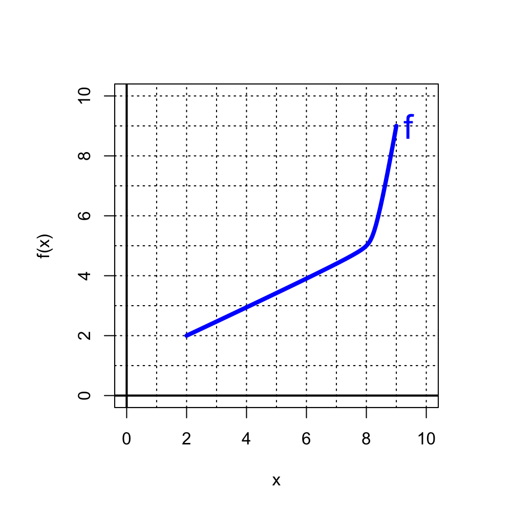

Which of the following red curves is a graph of the inverse function, $f^{-1}$?

- A

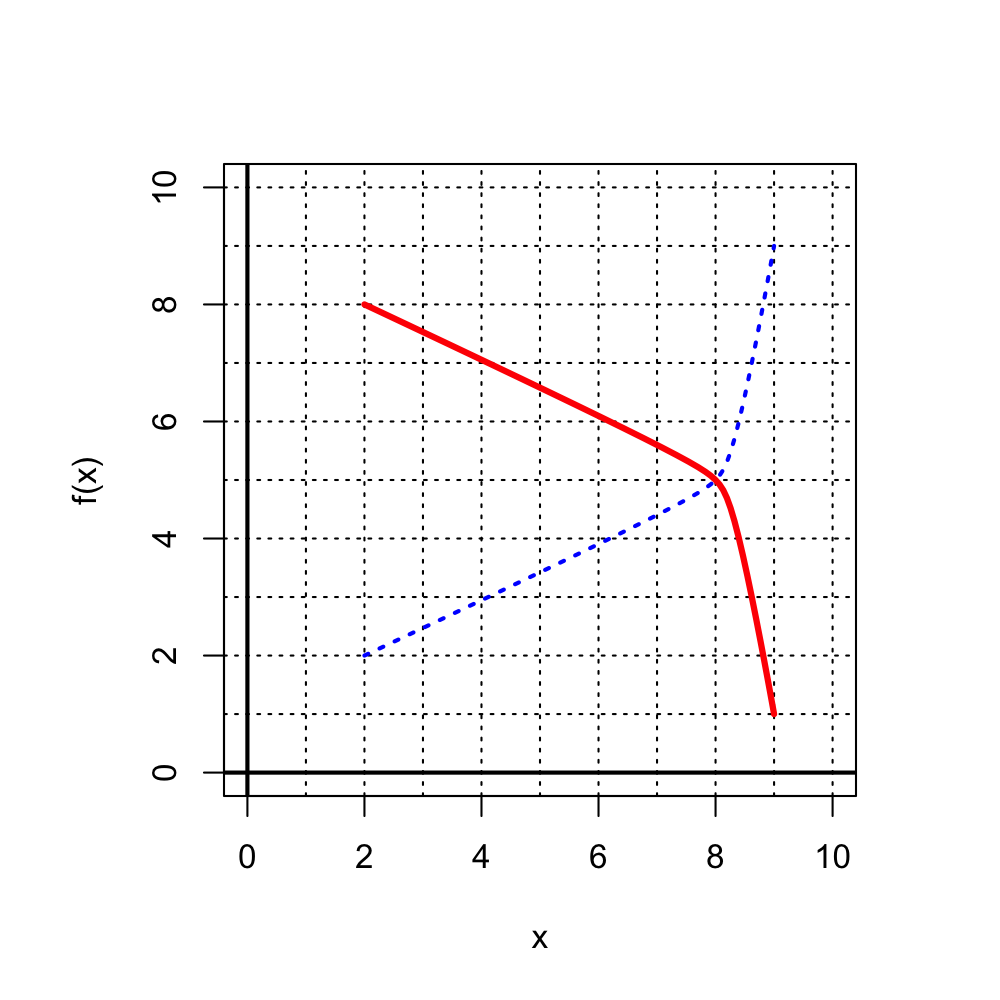

- B

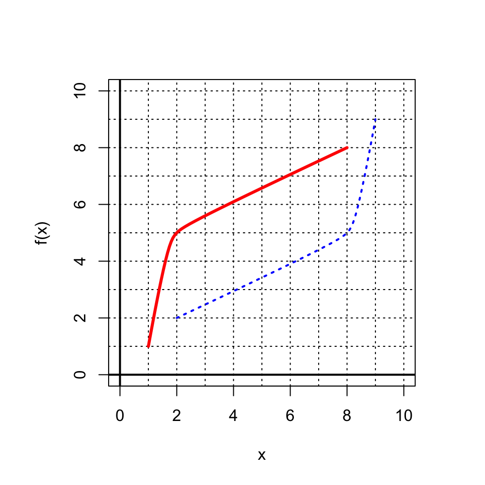

- C

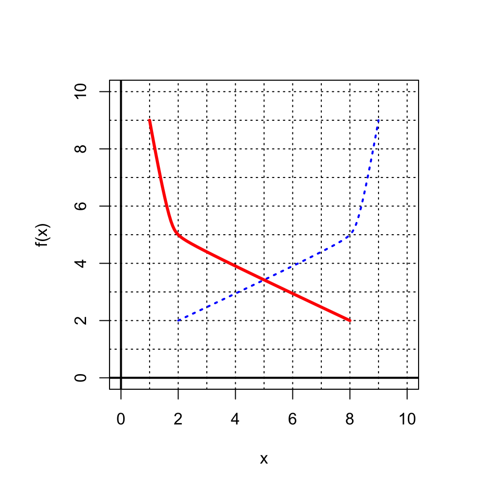

- D

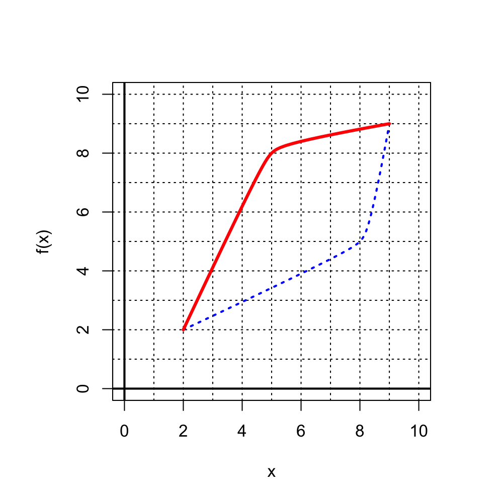

ABCD

The correct answer should have reflective symmetry across the $y=x$ line, also known as the 45$^\circ$ line.

So, the correct answer is D:

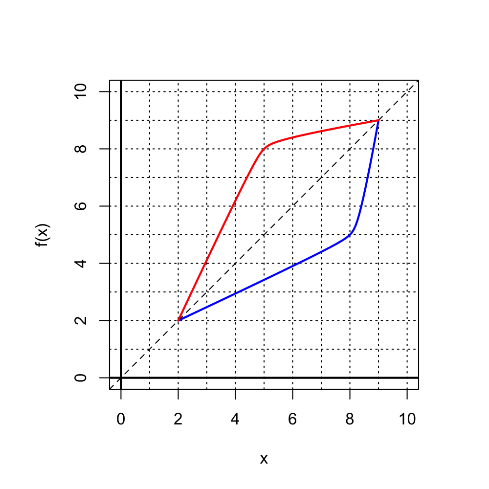

The [one-to-one](https://en.wikipedia.org/wiki/Injective_function) function $f$ is plotted below:

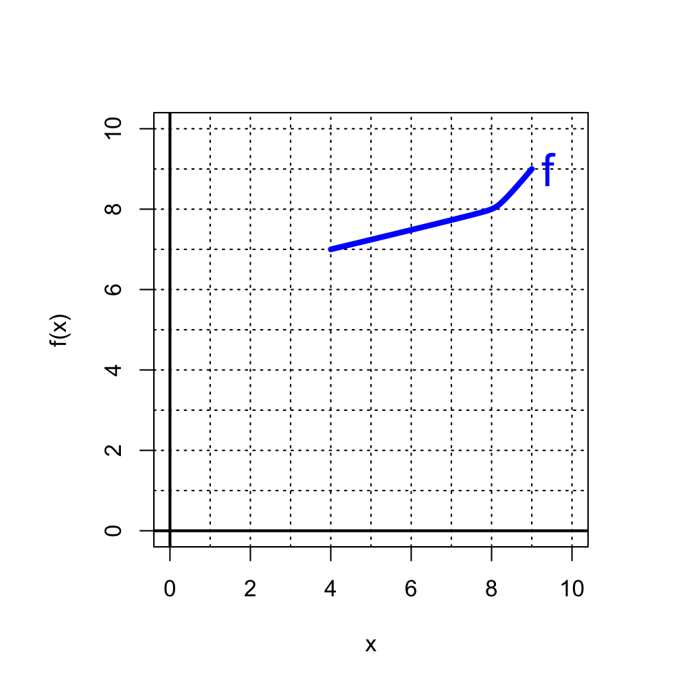

Which of the following red curves is a graph of the inverse function, $f^{-1}$?

- A

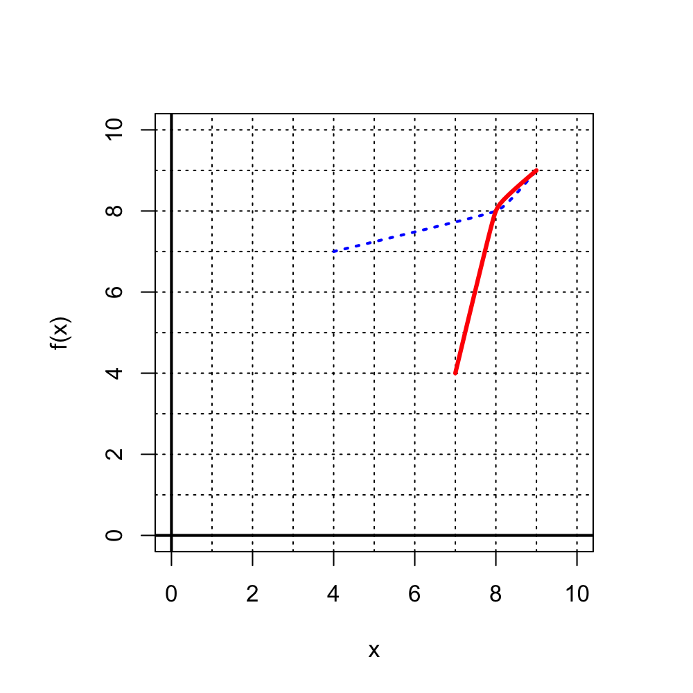

- B

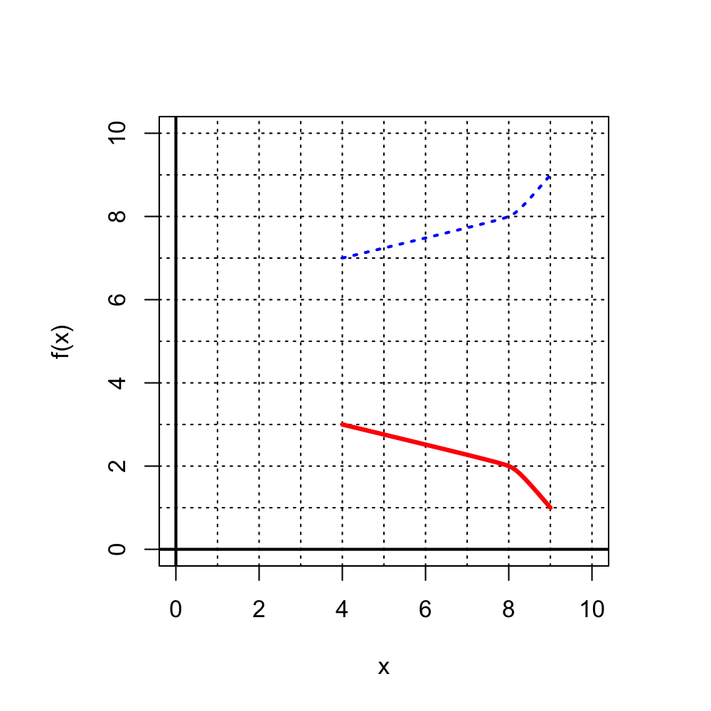

- C

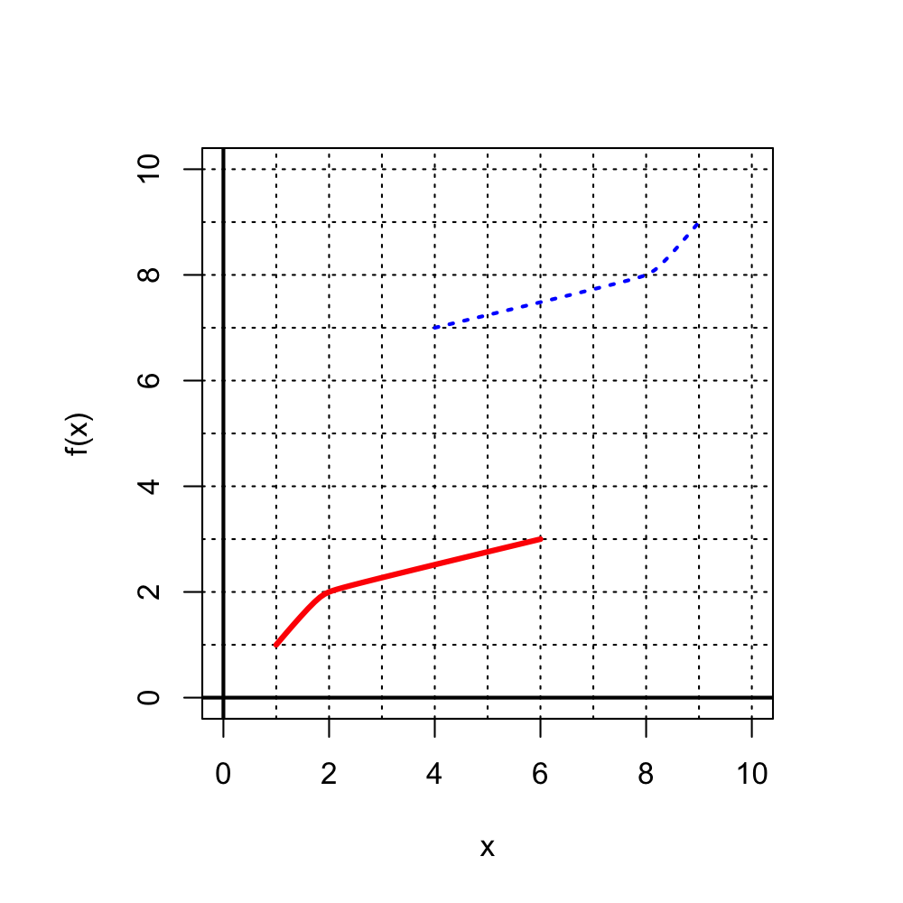

- D

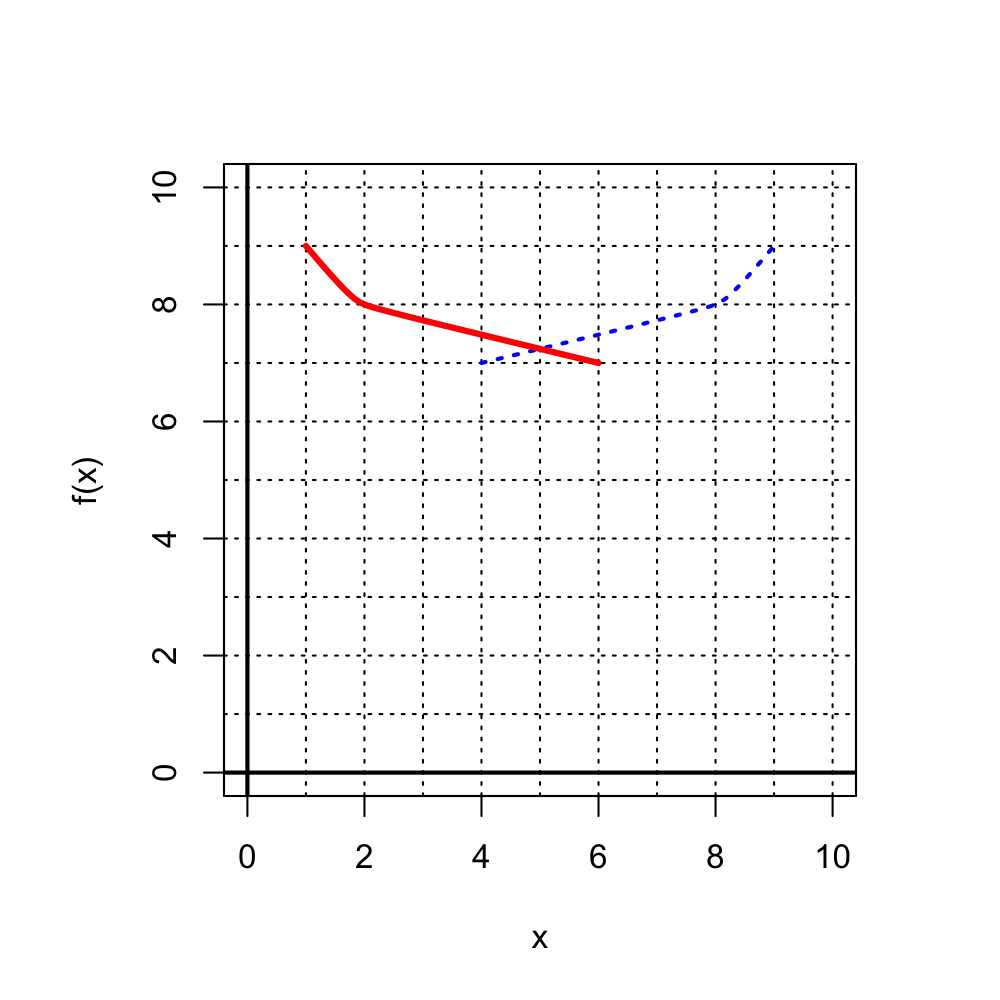

ABCD

The correct answer should have reflective symmetry across the $y=x$ line, also known as the 45$^\circ$ line.

So, the correct answer is A:

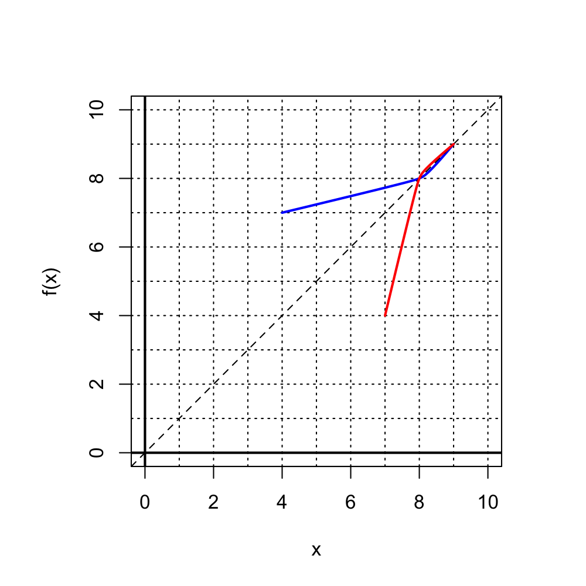

The [one-to-one](https://en.wikipedia.org/wiki/Injective_function) function $f$ is plotted below:

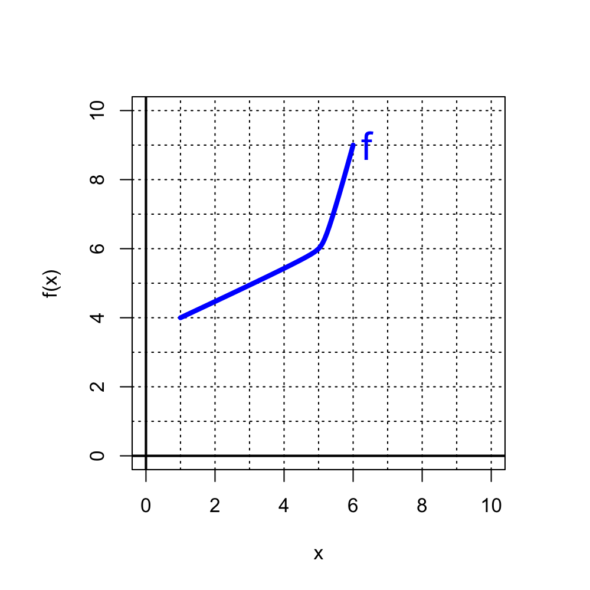

Which of the following red curves is a graph of the inverse function, $f^{-1}$?

- A

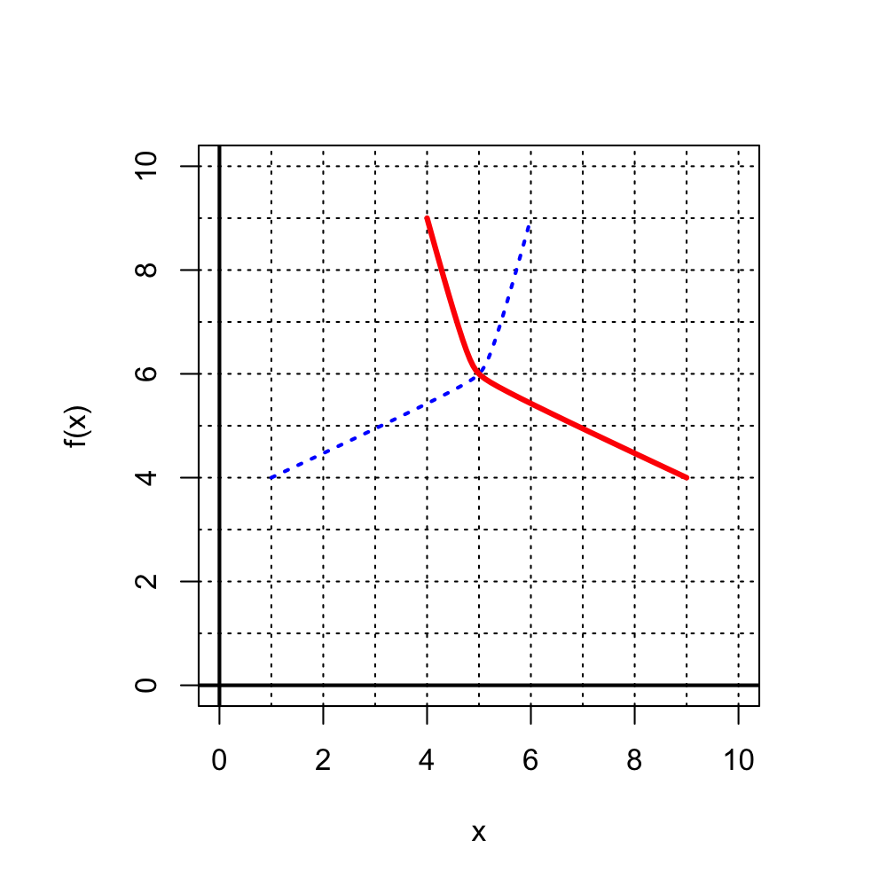

- B

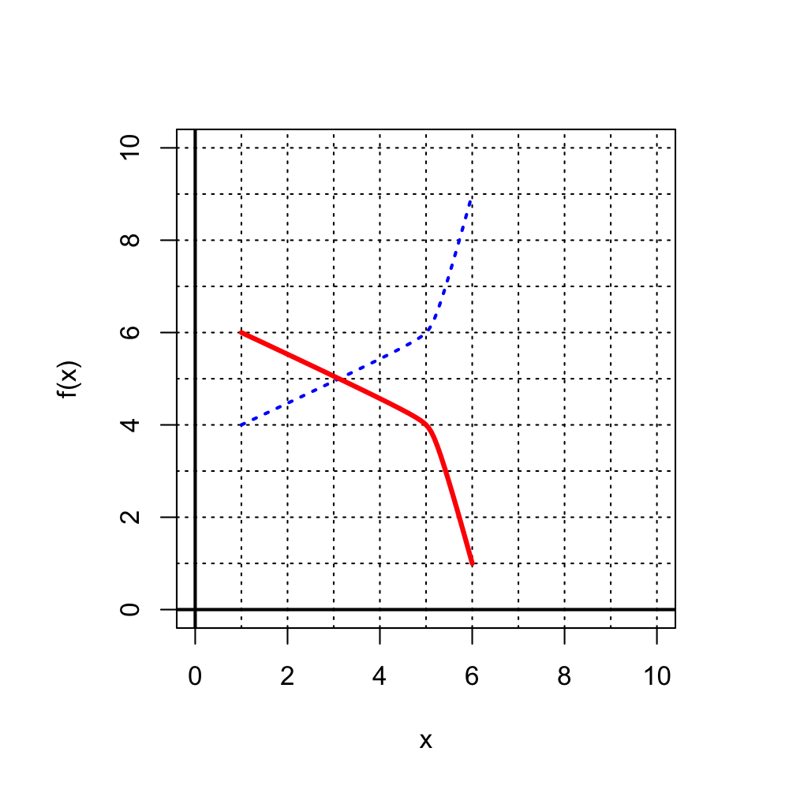

- C

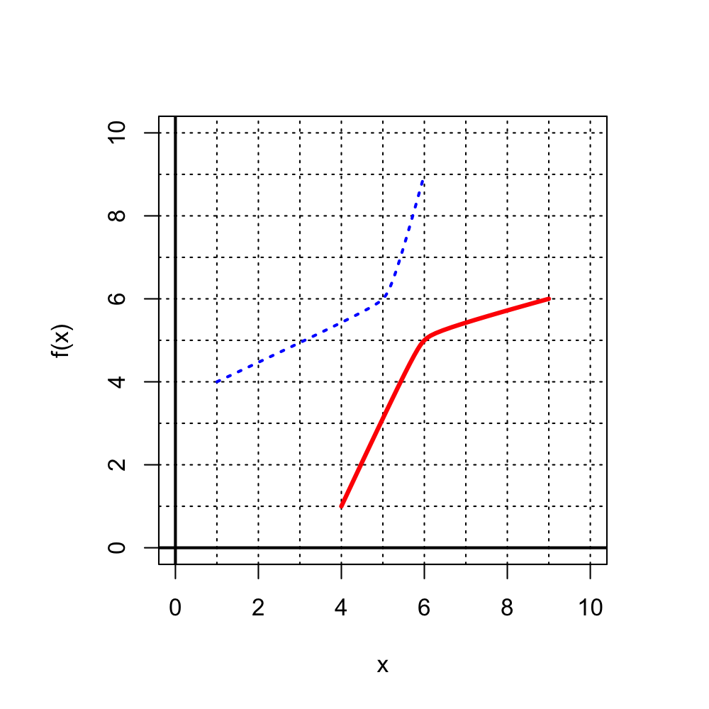

- D

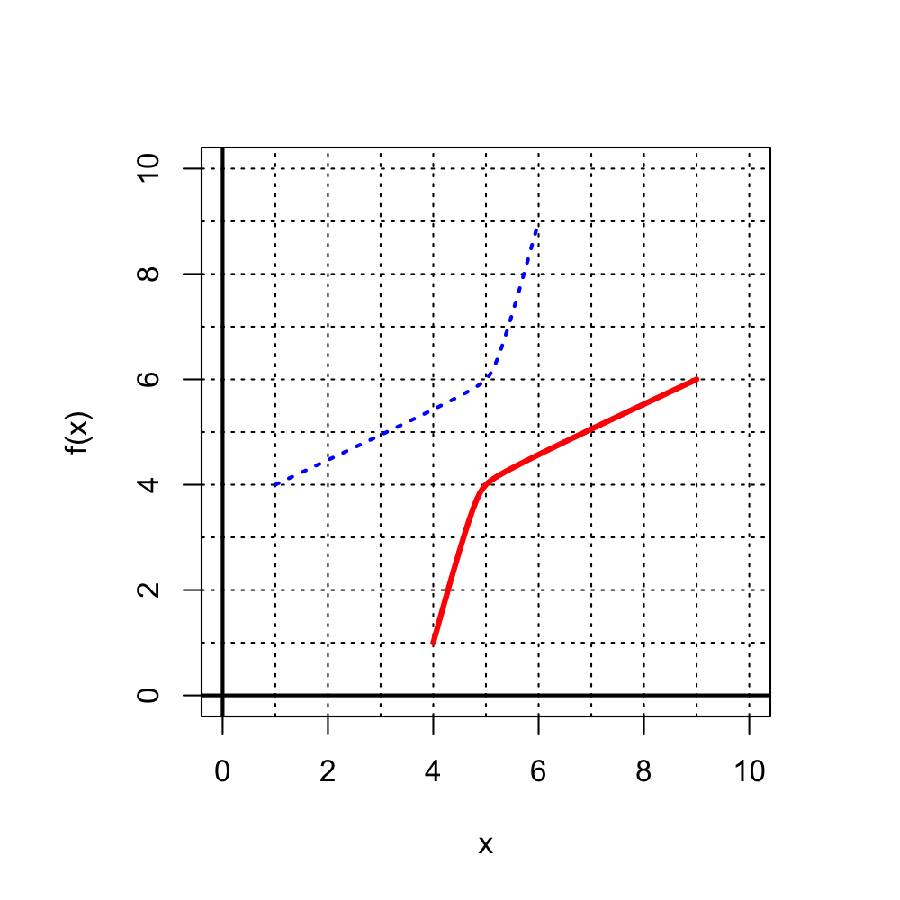

ABCD

The correct answer should have reflective symmetry across the $y=x$ line, also known as the 45$^\circ$ line.

So, the correct answer is C:

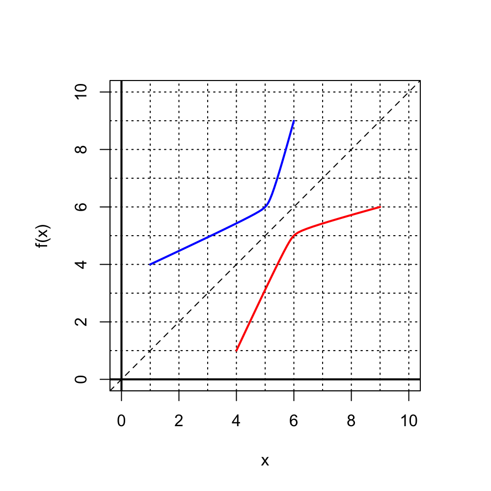

The [one-to-one](https://en.wikipedia.org/wiki/Injective_function) function $f$ is plotted below:

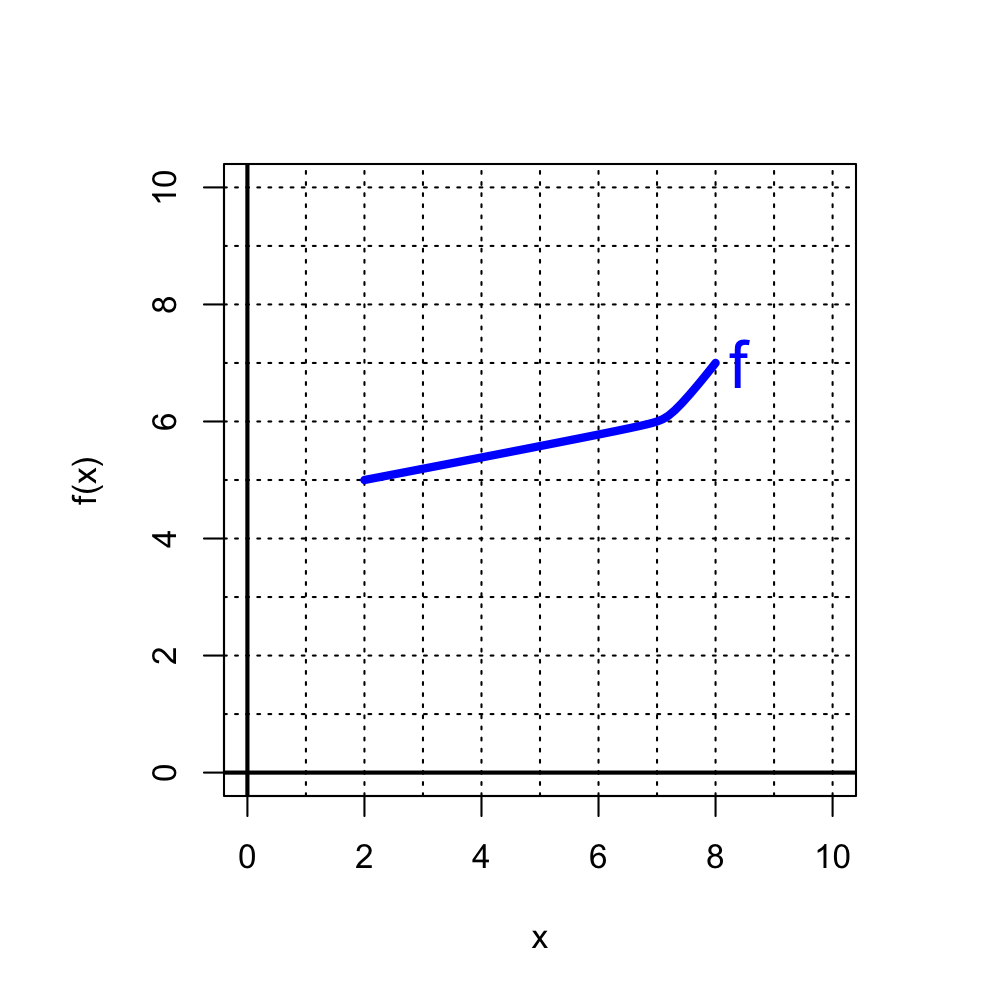

Which of the following red curves is a graph of the inverse function, $f^{-1}$?

- A

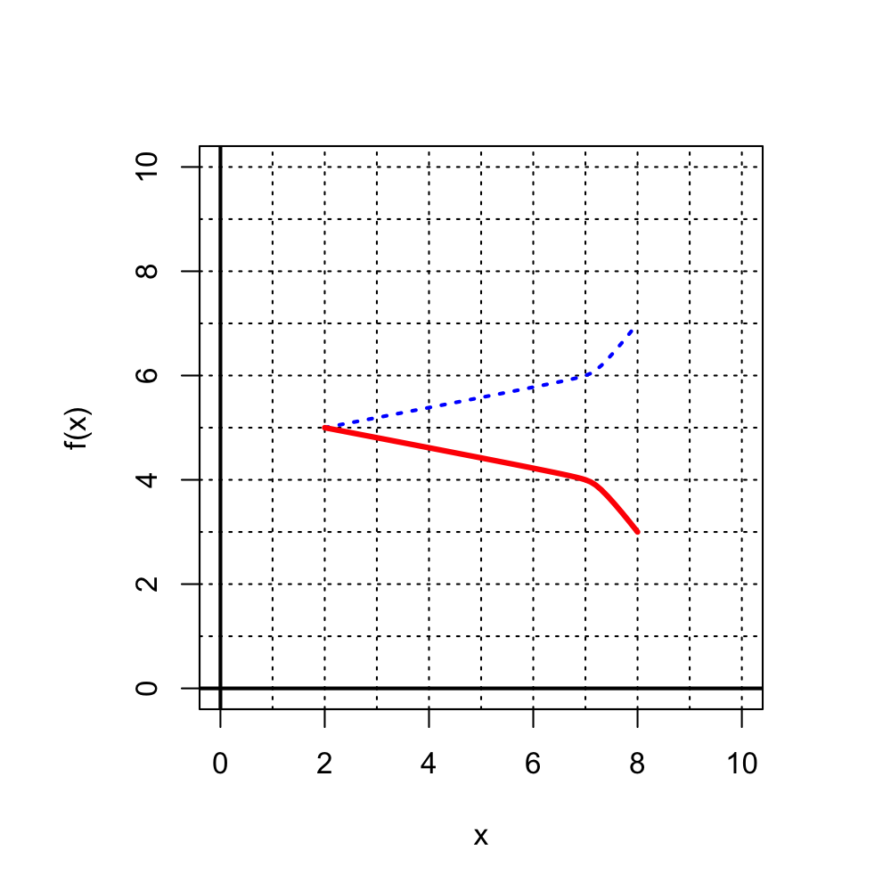

- B

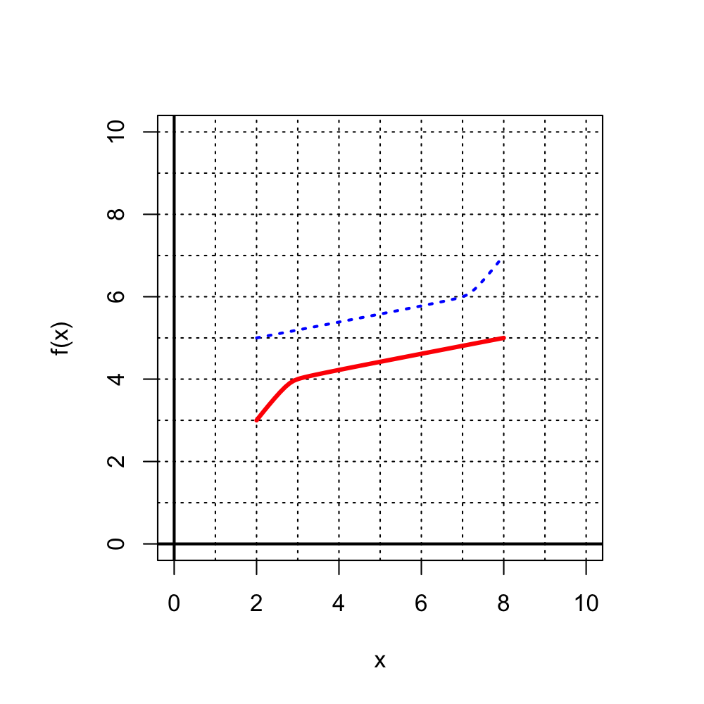

- C

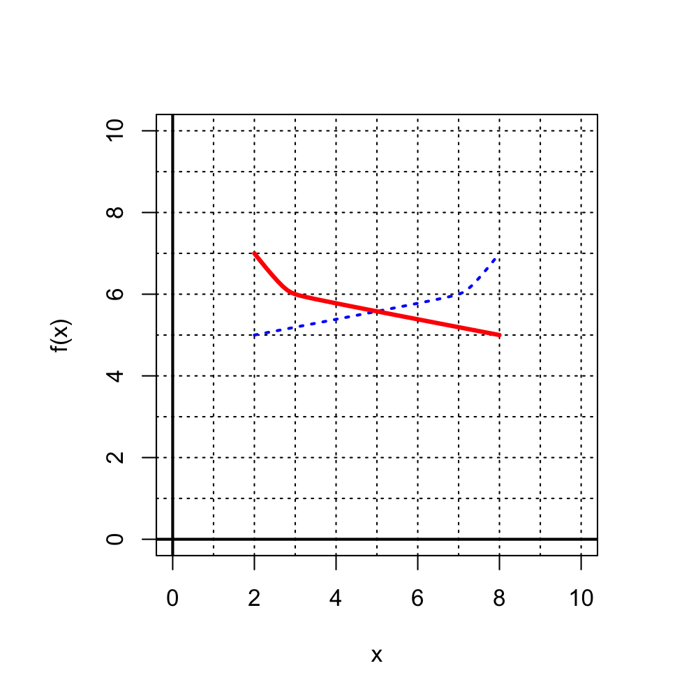

- D

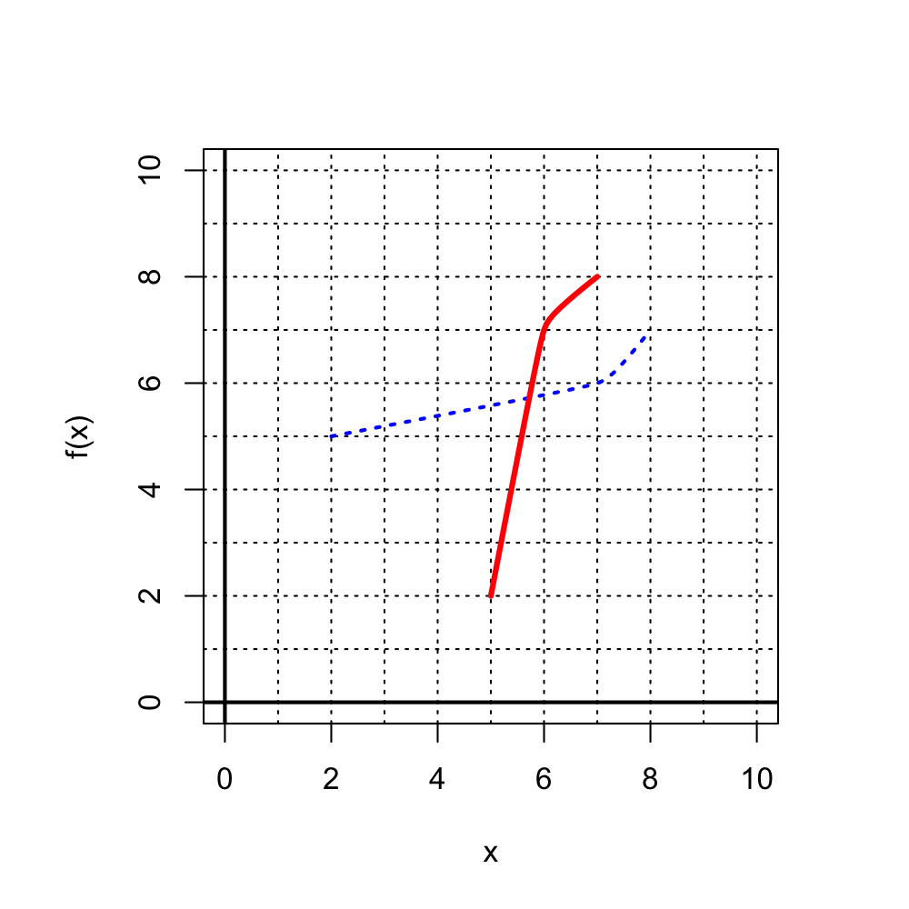

ABCD

The correct answer should have reflective symmetry across the $y=x$ line, also known as the 45$^\circ$ line.

So, the correct answer is D:

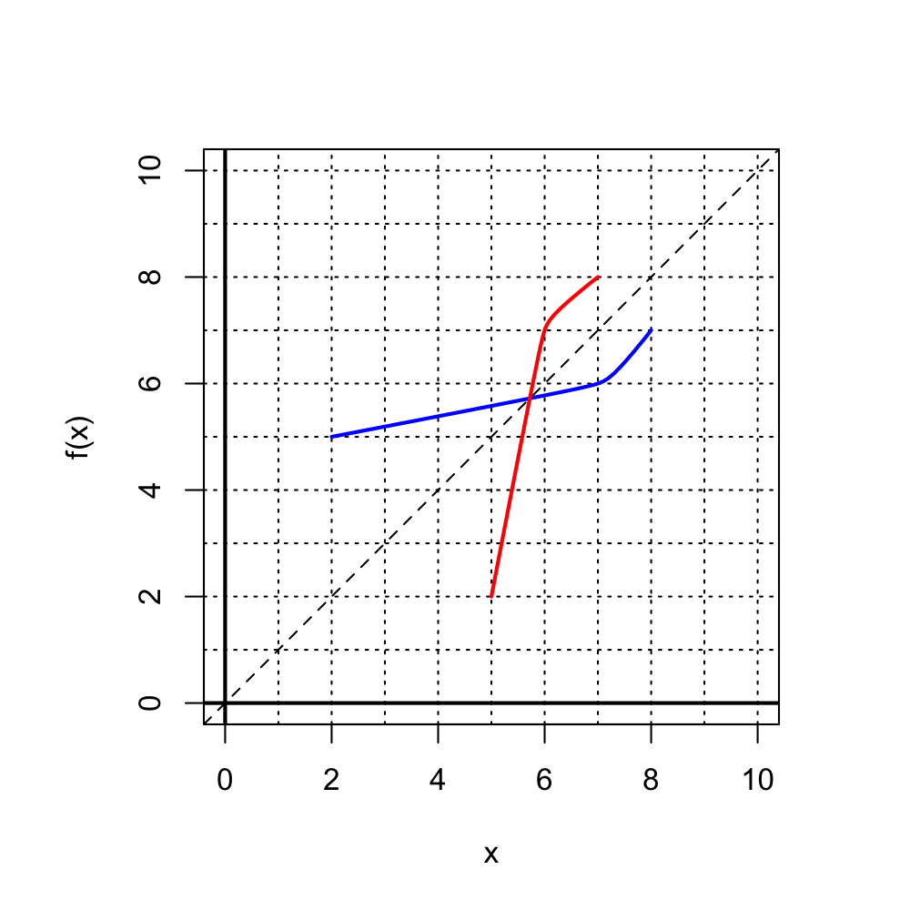